# Machine Learning for Automated Coding

This notebook gives a simple example of using supervised machine learning to automatically code the topic of a patent abstract. There’s a lot of code here – feel free to copy and paste much of it as you work on the exercises and you do your assignment. This is also only barely scratching the surface, and intended to be as transparent of an introduction as possible in terms of showing how everything is done. Of note, the `caret` package in R can be extremely helpful in doing some of what’s done here with much less code involved (see https://www.machinelearningplus.com/machine-learning/caret-package/ for more information). However, there’s somewhat of a learning curve associated with it, as well as the inability to see how everything works, so I only use the `caret` package to do a few things, like calculating precision and recall.

```r
# If you have not installed these, make sure to install first!

# Tidyverse and text analysis tools
library(tidyverse)
#library(tidyr)
library(tidytext)

# For decision trees
library(rpart)
library(rpart.plot)
library(rattle)

# For nearest neighbors
library(class)

# For ML evaluation
library(caret)
```

# Data

We scraped the data from PatentsView, then created labels of whether or not the patent was about cell biology or not.

> The labels here were generated using Latent Dirichlet Allocation, a form of unsupervised learning, to assign topics based on abstracts, so that I could easily assign a label to each one. In your assignments, you’ll be using hand-coded sentiments as the labels in the data that you work with.

```r
umd_abstracts <- read.csv('umd_patents.csv', stringsAsFactors = FALSE)
umd_abstracts$ID <- as.character(umd_abstracts$ID) # Need to make this character for later joins
glimpse(umd_abstracts)
```

```
Rows: 1,243
Columns: 5
$ ID              <chr> "1", "2", "3", "4", "5", "6", "7", "8", "9", "10", "11", "12", "13", "14", "15", "16", "17", "18", "…
$ patent_title    <chr> "Method for binding site identification by molecular dynamics simulation (silcs: site identification…
$ patent_year     <int> 2018, 2018, 2018, 2018, 2018, 2018, 2018, 2018, 2018, 2018, 2018, 2018, 2018, 2018, 2018, 2018, 2018…
$ patent_abstract <chr> "The invention describes an explicit solvent all-atom molecular dynamics methodology (SILCS: Site Id…
$ label           <chr> "False", "True", "True", "False", "False", "True", "False", "True", "False", "False", "True", "False…
```

Here, we have a few key variables. The ID variable is simply numbers from 1 to 1,243, denoting the unique patent. The patent title, patent year, and patent abstract are all included. Finally, the label denotes whether the topic of the patent was related to cell biology (True) or not (False). Our goal is to build a machine learning model that takes this data and is able to predict the topic of the abstract based on the content of the abstract.

These abstracts are exactly as we got them when we pulled from the PatentsView API. We need to do some cleaning first. After we do that, let’s take a look what the most common words are.

We want to do the following steps to turn this text data into features:

-**Tokenize:** Split up the abstracts into individual words

-**Stop Words:** Remove words that are too frequent and uninformative, like “a”, “an”, and “the”.

-**Bag of Words:** We want columns representing all words in the entire corpus, and the rows representing abstracts, with each cell indicating the counts of words in that abstract.

We’ll look at the distribution of words as we go to inform how we’re doing. Let’s first tokenize and then look at what words in our corpus. First, let’s tokenize and count the number of instances of each word. The key function we’re using here is `unnest_tokens`, which we’re using the break up the big abstract string for each patent into individual strings with just one word each.

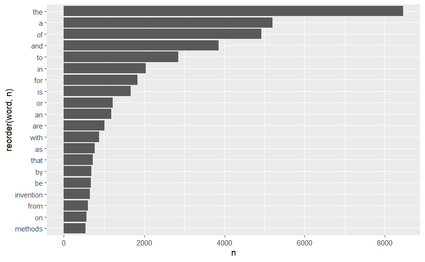

[output not shown]

```r
umd_abstracts %>%
  unnest_tokens(word, 'patent_abstract') %>%  # tokenize
  count(word, sort = TRUE) %>% # count by word
  arrange(desc(n)) %>% # Everything from this point on is just to graph
  head(20) %>%
  ggplot(aes(x = reorder(word, n), y = n)) +
  geom_bar(stat= 'identity') +
  coord_flip()
```

Looks like there are a lot of stop words being caught! Let’s take those out. To do this, we use the `stop_words` from the `tidytext` package and use an `anti_join` to remove all instances of that word.

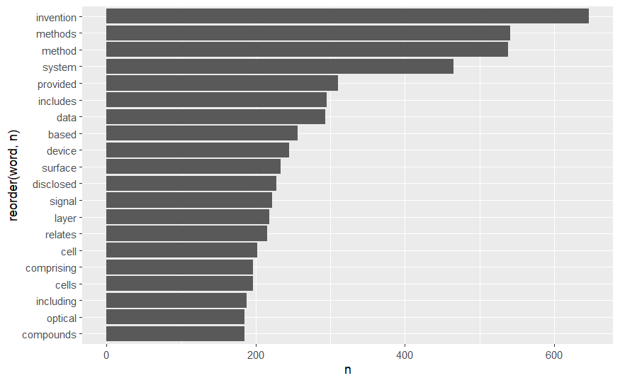

[output not shown]

```r
umd_abstracts %>%
  unnest_tokens(word, 'patent_abstract') %>%  # tokenize
  anti_join(stop_words)%>% # Remove stop words
  count(word, sort = TRUE) %>% # count by word
  arrange(desc(n)) %>% # Everything from this point on is just to graph
  head(20) %>%
  ggplot(aes(x = reorder(word, n), y = n)) +
  geom_bar(stat= 'identity') +
  coord_flip()
```

That looks better! Let’s also take a look at the distribution of word counts by using a histogram on a log scale.

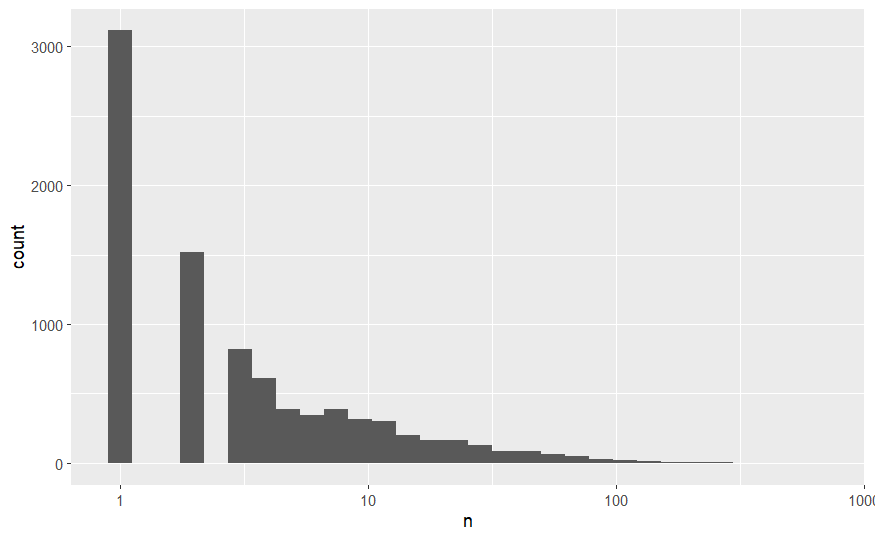

[output not shown]

```r
umd_abstracts %>%
  unnest_tokens(word, 'patent_abstract') %>%  # tokenize
  anti_join(stop_words)%>% # Remove stop words
  count(word, sort = TRUE) %>%
  ggplot(aes(n)) +
  geom_histogram() +
  scale_x_log10()
```

It looks like we have a lot of words that only happen once, or otherwise very infrequently. We’ll also remove some of the most infrequent words, as they are likely typos, or are so rare that they are not useful.

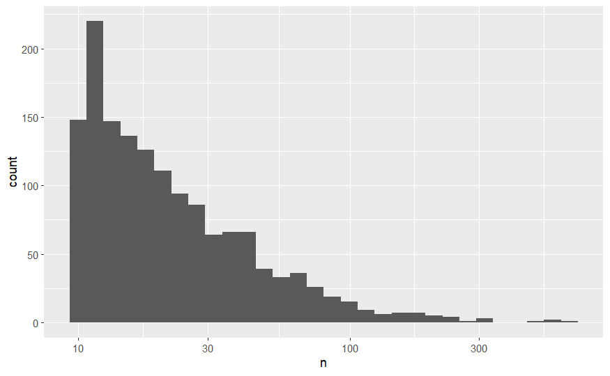

[output not shown]

```r
umd_abstracts %>%
  unnest_tokens(word, 'patent_abstract') %>%  # tokenize
  anti_join(stop_words)%>% # Remove stop words
  count(word, sort = TRUE) %>% # count by word
  filter(n >= 10) %>%  # Remove words that occur less than 10 times
  ggplot(aes(n)) +
  geom_histogram() +
  scale_x_log10()
```

Now that we’ve explored the data a little bit and know what steps we should take to clean it up, we can create our features. From this exercise, we know we need to tokenize, remove stop words, and remove infrequent words. We can also take additional steps at this stage to clean up the data a bit more. For example, we might consider removing all numbers or digits. We can think about stemming in order to group similar words together under a single root (e.g., invent, invention, inventor). If we were to stem (this step is optional, and it’s actually possible your models run better without stemming), it might look something like this:

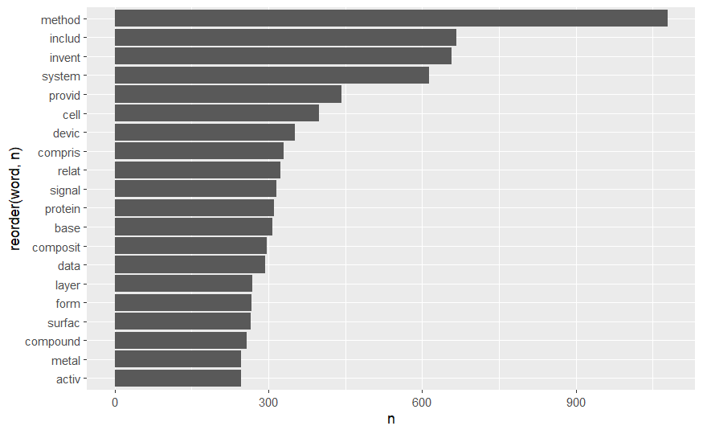

[output not shown]

```r
# NOTE: This uses the corpus package, which we did not bring in at the beginning
umd_abstracts %>%
  unnest_tokens(word, 'patent_abstract') %>%  # tokenize
  anti_join(stop_words)%>% # Remove stop words
  mutate(word = corpus::text_tokens(word, stemmer = "en") %>% unlist()) %>% # add stemming process
  count(word, sort = TRUE) %>% # count by word
  filter(n >= 10) %>%  # Remove words that occur less than 10 times
  arrange(desc(n)) %>% # Everything from this point on is just to graph
  head(20) %>%
  ggplot(aes(x = reorder(word, n), y = n)) +
  geom_bar(stat= 'identity') +
  coord_flip()
```